# National Park Data Project

Laura Maple

2023

Our National Parks have some of the best views, coolest geology, and most diverse species. I love travel and the outdoors and have combined those hobbies into a love for our National Parks. There are currently 63 parks, with the newest being New River Gorge in West Virginia (established 2020). I wanted to look at data for a few different aspects to our parks, such as annual visitation, land area, and location. I used data from the following three sources: https://en.wikipedia.org/wiki/List_of_national_parks_of_the_United_States, https://www.nps.gov/subjects/lwcf/acreagereports.htm, https://irma.nps.gov/Stats/Reports/National. The tables and plots below were created with Rstudio.

My first step was importing the annual visitation data for each park. Unfortunately, this data included every NPS site (National Historic Sites, National Monuments, etc.), so I had to filter through the data for only the National Parks. Then, I added 5, 10, and 15 year means for each park’s annual visitation. I then did the same with percent increases.

```r
visitor.data <- read.csv("AnnualVisitationByPark.csv",
                         check.names = FALSE, col.names = c("Park Name", 2008:2022))
parknamefile <- read.csv("list_of_park_names.csv", header = FALSE)
park_names <- c(parknamefile$V1)
#import a list of park names as a vector

park.data <- visitor.data %>% filter(str_detect(visitor.data$"Park Name", paste(park_names, collapse = "|")))
#only want National Parks, not all NPS sites

park.data$"15-year mean" <- rowMeans(park.data[ , 2:16], na.rm = TRUE)
park.data$"10-year mean" <- rowMeans(park.data[ , 7:16], na.rm = TRUE)
park.data$"5-year mean" <- rowMeans(park.data[ , 12:16], na.rm = TRUE)
#adding columns with some means of annual visitation

percent_increase <- function(new.num, og.num) {
  return (((new.num - og.num)/og.num) * 100)
}
park.data$"5-year % increase" <- percent_increase(park.data[ , 16], park.data[ , 12])
park.data$"10-year % increase" <- percent_increase(park.data[ , 16], park.data[ , 7])
park.data$"15-year % increase" <- percent_increase(park.data[ , 16], park.data[ , 2])
#created  function to measure percent increases in annual visitation between two years
#then applied it to 3 pairs: a 5-year, 10-year, and 15-year spread

park.data <- rbind(park.data[1 , ], park.data[44 , ], park.data[2:43 , ], park.data[45:63 , ])
rownames(park.data) = 1:63
#rearranging park.data so that the order of the parks is alphabetical with American Samoa being 2nd
head(park.data)
```

```
##                         Park Name    2008    2009    2010    2011    2012
## 1                       Acadia NP 2075857 2227698 2504208 2374645 2431052
## 2 National Park of American Samoa    3683    3242    3006    8716   10440
## 3                       Arches NP  928795  996312 1014405 1040758 1070577
## 4                     Badlands NP  845734  933918  977778  870741  883406
## 5                     Big Bend NP  362512  363905  372330  361862  292055
## 6                     Biscayne NP  686062  437745  467612  476077  495613
##      2013    2014    2015    2016    2017    2018    2019    2020    2021
## 1 2254922 2563129 2811184 3303393 3509271 3537575 3437286 2669034 4069098
## 2   17919   13953   13892   28892   69468   28626   60006    4819    8495
## 3 1082866 1284767 1399247 1585718 1539028 1663557 1659702 1238083 1806865
## 4  892372  868094  989354  996263 1054325 1008942  970998  916932 1224226
## 5  316953  314102  381747  388290  440276  440091  463832  393907  581220
## 6  486848  525745  508164  514709  446961  469253  708522  402770  705655
##      2022 15-year mean 10-year mean 5-year mean 5-year % increase
## 1 3970260    2915907.5    3212515.2   3536650.6        12.2311188
## 2    1887      18469.6      24795.7     20766.6       -93.4080905
## 3 1460652    1318088.8    1472048.5   1565771.8       -12.1970573
## 4 1006809     962659.5     992831.5   1025581.4        -0.2114096
## 5  514107     399145.9     423452.5    478631.4        16.8183398
## 6  701023     535517.3     546965.0    597444.6        49.3912665
##   10-year % increase 15-year % increase
## 1           76.07084          91.258839
## 2          -89.46928         -48.764594
## 3           34.88760          57.263120
## 4           12.82391          19.045586
## 5           62.20291          41.817926
## 6           43.99217           2.180707
```

My next step was importing acreage data. This data also includes all NPS sites, so I had to filter through this data as well. I also realized about halfway through tidying this data that parks with a “National Preserve” part of the park had two entries in the data: one for the preserve and one for the park. I decided to combine those acreage entries because they are part of the same park system. Then I added the acreage to our main table: park.data.

```r
acreage.data <- read.csv("NPS-Acreage-3-31-2022.csv", check.names = FALSE)
head(acreage.data)
```

```
##                  Area Name Region State NPS Fee Acres NPS Less Than Fee Acres
## 1    A LINCOLN BIRTHPL NHP      1    KY        344.50                    0.00
## 2                ACADIA NP      1    ME      37478.70                10707.90
## 3                ADAMS NHP      1    MA          9.17                    0.00
## 4 AFRICAN BURIAL GROUND NM      1    NY          0.35                    0.00
## 5     AGATE FOSSIL BEDS NM      5    NE       2270.33                  459.75
## 6         ALAGNAK WILD RVR     11    AK      26417.85                    0.00
##   Other Federal Fee Acres Subtotal Federal Acres Other Public Acres
## 1                    0.00                 344.50               0.00
## 2                   21.77               48208.37              48.22
## 3                    0.00                   9.17               4.00
## 4                    0.00                   0.35               0.00
## 5                    0.00                2730.08              24.43
## 6                    0.00               26417.85            2265.00
##   Private Acres Subtotal Non-Federal Acres Gross Area Acres
## 1          0.00                       0.00           344.50
## 2        814.81                     863.03         49071.40
## 3         10.65                      14.65            23.82
## 4          0.00                       0.00             0.35
## 5        303.36                     327.79          3057.87
## 6       1981.94                    4246.94         30664.79
```

```r
acreage.data <- acreage.data %>% select("Area Name", "Gross Area Acres")
#wanted to add data about park land area to park.data so imported it

newparknames <- c(parknamefile$V2)
#had to use a new list of park names since this data had different names
temp.data <- acreage.data %>% filter(str_detect(acreage.data$"Area Name", paste(toupper(newparknames), collapse = "|")))
temp.data <- temp.data %>% filter(!str_detect(temp.data$`Area Name`, "T ROOSEVELT BIRTHPLACE NHS|T ROOSEVELT INAUG NHS|T ROOSEVELT ISLAND"))
#had to exclude other NPS sides with "T Roosevelt" in the name

combine_nps_sites <- function(df, x, y){
  df[y , 2] <- df[x , 2] + df[y , 2]
  df <- df[-x , ]
}
temp.data <- combine_nps_sites(temp.data, 16, 17)
temp.data <- combine_nps_sites(temp.data, 18, 19)
temp.data <- combine_nps_sites(temp.data, 21, 22)
temp.data <- combine_nps_sites(temp.data, 26, 27)
temp.data <- combine_nps_sites(temp.data, 35, 36)
temp.data <- combine_nps_sites(temp.data, 39, 40)
temp.data <- combine_nps_sites(temp.data, 56, 57)
temp.data <- combine_nps_sites(temp.data, 60, 61)
#parks that have a NP and a NPRES aspect were listed as separate land areas in this data
#so I wrote a function that would sum the two land areas together and delete the extra entry

acreage.data <- temp.data

acreage.data <- rbind(acreage.data[1 , ], acreage.data[46 , ], acreage.data[2:45 , ], acreage.data[47:63 , ])
#again, wanted to alphabetize the list of park names so that American Samoa was second
rownames(acreage.data) = 1:63

head(acreage.data)
```

```
##              Area Name Gross Area Acres
## 1            ACADIA NP         49071.40
## 2 NP OF AMERICAN SAMOA          8256.67
## 3            ARCHES NP         76678.98
## 4          BADLANDS NP        242755.94
## 5          BIG BEND NP        801163.21
## 6          BISCAYNE NP        172971.11
```

```r
park.data$"Acreage" <- acreage.data$`Gross Area Acres`
#tacked on the Acreage column from the acreage data to park.data

head(park.data)
```

```
##                         Park Name    2008    2009    2010    2011    2012
## 1                       Acadia NP 2075857 2227698 2504208 2374645 2431052
## 2 National Park of American Samoa    3683    3242    3006    8716   10440
## 3                       Arches NP  928795  996312 1014405 1040758 1070577
## 4                     Badlands NP  845734  933918  977778  870741  883406
## 5                     Big Bend NP  362512  363905  372330  361862  292055
## 6                     Biscayne NP  686062  437745  467612  476077  495613
##      2013    2014    2015    2016    2017    2018    2019    2020    2021
## 1 2254922 2563129 2811184 3303393 3509271 3537575 3437286 2669034 4069098
## 2   17919   13953   13892   28892   69468   28626   60006    4819    8495
## 3 1082866 1284767 1399247 1585718 1539028 1663557 1659702 1238083 1806865
## 4  892372  868094  989354  996263 1054325 1008942  970998  916932 1224226
## 5  316953  314102  381747  388290  440276  440091  463832  393907  581220
## 6  486848  525745  508164  514709  446961  469253  708522  402770  705655
##      2022 15-year mean 10-year mean 5-year mean 5-year % increase
## 1 3970260    2915907.5    3212515.2   3536650.6        12.2311188
## 2    1887      18469.6      24795.7     20766.6       -93.4080905
## 3 1460652    1318088.8    1472048.5   1565771.8       -12.1970573
## 4 1006809     962659.5     992831.5   1025581.4        -0.2114096
## 5  514107     399145.9     423452.5    478631.4        16.8183398
## 6  701023     535517.3     546965.0    597444.6        49.3912665
##   10-year % increase 15-year % increase   Acreage
## 1           76.07084          91.258839  49071.40
## 2          -89.46928         -48.764594   8256.67
## 3           34.88760          57.263120  76678.98
## 4           12.82391          19.045586 242755.94
## 5           62.20291          41.817926 801163.21
## 6           43.99217           2.180707 172971.11
```

I found two tables from Wikipedia that I wanted to use. One table had location data and the date each park was established. This data uploaded from the csv file in a very messy way, so I had to use string functions to extract the state/territory of each park as well as the longitude and latitude. The date was easier; I simply had to convert to a date/time format. Finally, I inner joined the cleaned up table with park.data.

```r
wikidata <- read.csv("wiki NP table.csv", check.names = FALSE)
rownames(wikidata) = 1:63
wikidata <- wikidata %>% select("Name", "Location", "Date established as park")
location.data <- c(wikidata$Location)
head(wikidata)
```

```
##             Name
## 1         Acadia
## 2 American Samoa
## 3         Arches
## 4       Badlands
## 5       Big Bend
## 6       Biscayne
##                                                                                                                      Location
## 1                                       Maine\n44Â°21â\200²N 68Â°13â\200²Wï»¿ / ï»¿44.35Â°N 68.21Â°Wï»¿ / 44.35; -68.21ï»¿ (Acadia)
## 2 American Samoa\n14Â°15â\200²S 170Â°41â\200²Wï»¿ / ï»¿14.25Â°S 170.68Â°Wï»¿ / -14.25; -170.68ï»¿ (National Park of American Samoa)
## 3                                     Utah\n38Â°41â\200²N 109Â°34â\200²Wï»¿ / ï»¿38.68Â°N 109.57Â°Wï»¿ / 38.68; -109.57ï»¿ (Arches)
## 4                           South Dakota\n43Â°45â\200²N 102Â°30â\200²Wï»¿ / ï»¿43.75Â°N 102.50Â°Wï»¿ / 43.75; -102.50ï»¿ (Badlands)
## 5                                  Texas\n29Â°15â\200²N 103Â°15â\200²Wï»¿ / ï»¿29.25Â°N 103.25Â°Wï»¿ / 29.25; -103.25ï»¿ (Big Bend)
## 6                                   Florida\n25Â°39â\200²N 80Â°05â\200²Wï»¿ / ï»¿25.65Â°N 80.08Â°Wï»¿ / 25.65; -80.08ï»¿ (Biscayne)
##   Date established as park
## 1        February 26, 1919
## 2         October 31, 1988
## 3        November 12, 1971
## 4        November 10, 1978
## 5            June 12, 1944
## 6            June 28, 1980
```

```r
#found a table on wikipedia that listed location of parks and the date each was est.

wikidata$"State(s) or Territory" <- sub("\n.*", "", location.data)
#location data was a mess so I used cat(location.data) many times
#wanted to extract the state/territory from the coordinates

location.data <- str_split(location.data, '/') %>% sapply(., "[[", 3)
location.data <- sub("ï.*", "", location.data) %>% sub(" ", "", .) %>% str_split(., ";")
wikidata$"Latitude" <- sapply(location.data, "[[", 1) %>% as.numeric()
wikidata$"Longitude" <- sapply(location.data, "[[", 2) %>% sub(" ", "", .) %>% as.numeric()
#pulled out the latitudinal/longitudinal coordinates and sent them to separate columns

wikidata <- wikidata[ , -2]
#got rid of the messy location column

wikidata$`Date established as park` <- wikidata$`Date established as park` %>%  as.Date(., "%B %d, %Y")
#converted date column to date/time format
wikidata$Name <- park.data$`Park Name`
#replaced the names with the same column from park.data
colnames(wikidata)[1] = "Park Name"
park.data <- inner_join(park.data, wikidata, by = "Park Name")
#joined the two dataframes together

head(park.data)
```

```
##                         Park Name    2008    2009    2010    2011    2012
## 1                       Acadia NP 2075857 2227698 2504208 2374645 2431052
## 2 National Park of American Samoa    3683    3242    3006    8716   10440
## 3                       Arches NP  928795  996312 1014405 1040758 1070577
## 4                     Badlands NP  845734  933918  977778  870741  883406
## 5                     Big Bend NP  362512  363905  372330  361862  292055
## 6                     Biscayne NP  686062  437745  467612  476077  495613
##      2013    2014    2015    2016    2017    2018    2019    2020    2021
## 1 2254922 2563129 2811184 3303393 3509271 3537575 3437286 2669034 4069098
## 2   17919   13953   13892   28892   69468   28626   60006    4819    8495
## 3 1082866 1284767 1399247 1585718 1539028 1663557 1659702 1238083 1806865
## 4  892372  868094  989354  996263 1054325 1008942  970998  916932 1224226
## 5  316953  314102  381747  388290  440276  440091  463832  393907  581220
## 6  486848  525745  508164  514709  446961  469253  708522  402770  705655
##      2022 15-year mean 10-year mean 5-year mean 5-year % increase
```

[output cut: 20 more lines]

I was curious if a park being close to other parks increased visitation. In order to do that, I had to move the coordinates to a separate table and find the distance between each park. Then I took the 5 closest parks and averaged them to get the average distance of the 5 closest parks to each park.

```r
coords <- park.data %>% select("Longitude", "Latitude")
#wanted to isolate just the coordinates
head(coords)
```

```
##   Longitude Latitude
## 1    -68.21    44.35
## 2   -170.68   -14.25
## 3   -109.57    38.68
## 4   -102.50    43.75
## 5   -103.25    29.25
## 6    -80.08    25.65
```

```r
distmatrix <- distm(coords, fun = distGeo) %>% as.data.frame()
#used geosphere package to calculate distance in meters between every park
rownames(distmatrix) = 1:63
colnames(distmatrix) = 1:63
distmatrix[distmatrix == 0] <- NA
head(distmatrix[ , 1:6])
```

```
##          1        2         3         4       5        6
## 1       NA 12092378 3471603.4 2728573.1 3510361  2334743
## 2 12092378       NA 8637110.9 9422271.8 8691355 10748382
## 3  3471603  8637111        NA  817079.1 1197236  3114878
## 4  2728573  9422272  817079.1        NA 1610449  2854395
## 5  3510361  8691355 1197235.8 1610448.6      NA  2321006
## 6  2334743 10748382 3114878.1 2854395.4 2321006       NA
```

```r
meanmin <- function(nums){
  mean(sort(nums)[1:5], na.rm = TRUE)
}
#created a function to find the closest 5 parks and average the distance

distancelist <- apply(distmatrix, 1, meanmin)
park.data$"Average distance of 5 nearest parks (m)" <- distancelist
#added the mean distance of 5 closest parks to park.data

park.data
```

```
##                          Park Name    2008    2009    2010    2011    2012
## 1                        Acadia NP 2075857 2227698 2504208 2374645 2431052
## 2  National Park of American Samoa    3683    3242    3006    8716   10440
## 3                        Arches NP  928795  996312 1014405 1040758 1070577
## 4                      Badlands NP  845734  933918  977778  870741  883406
## 5                      Big Bend NP  362512  363905  372330  361862  292055
## 6                      Biscayne NP  686062  437745  467612  476077  495613
## 7  Black Canyon of the Gunnison NP  160185  171451  176344  168336  192570
## 8                  Bryce Canyon NP 1043321 1216377 1285492 1296000 1385352
## 9                   Canyonlands NP  436715  436241  435908  473773  452952
## 10                 Capitol Reef NP  604811  617208  662661  668834  673345
## 11             Carlsbad Caverns NP  400381  432639  428524  365000  381058
## 12              Channel Islands NP  332177  348745  277515  242756  249594
## 13                     Congaree NP  104913  122970  121208  120166  109685
## 14                  Crater Lake NP  415686  446516  448319  423551  447251
```

[output cut: 369 more lines]

This was the second table I found on Wikipedia. It showed how many parks each state/territory has and if it shares the park with another state/territory.

```r
#found another table from wikipedia
#this one shows how many national parks each state has
parkstates <- read.csv("wiki NP by state_encode.csv", check.names = FALSE, na.strings = "+IBQ-")
parkstates[is.na(parkstates)] = 0
parkstates
```

```
##                  State Total parks Exclusive parks Shared parks
## 1           California           9               8            1
## 2               Alaska           8               8            0
## 3                 Utah           5               5            0
## 4             Colorado           4               4            0
## 5              Arizona           3               3            0
## 6              Florida           3               3            0
## 7           Washington           3               3            0
## 8               Hawaii           2               2            0
## 9           New Mexico           2               2            0
## 10        South Dakota           2               2            0
## 11               Texas           2               2            0
## 12             Montana           2               1            1
## 13              Nevada           2               1            1
## 14             Wyoming           2               1            1
```

[output cut: 18 more lines]

The chart below shows a timeline of when each park was established as a National Park. Many parks were owned by the government before this date, but they may have been National Monuments, for example.

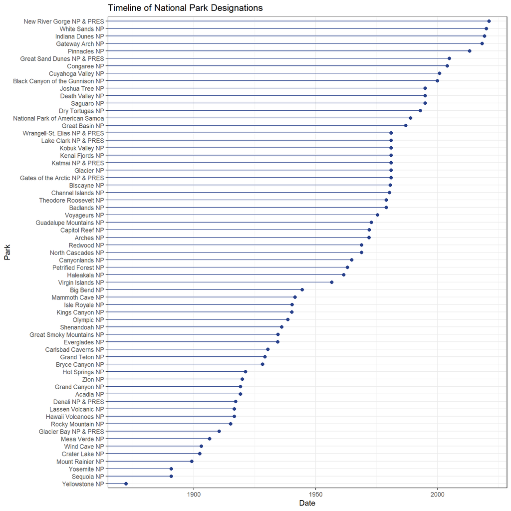

```r
park.data %>%
  mutate(`Park Name` = fct_reorder(`Park Name`, `Date established as park`)) %>%
  #wanted the chart to be in order of dates
  ggplot(mapping = aes(y = `Date established as park`, x = `Park Name`)) +
  geom_segment(aes(x = `Park Name`, xend = `Park Name`, y = structure(-Inf, class = "Date"),
                    yend = `Date established as park`), color = "royalblue4") +
  coord_flip() +
  geom_point(color = "royalblue4", size = 2) +
  theme_bw() +
  labs(y = "Date", x = "Park", title = "Timeline of National Park Designations")
```

This shows if there might be a correlation between park size and visitation. It does not seem clear either way.

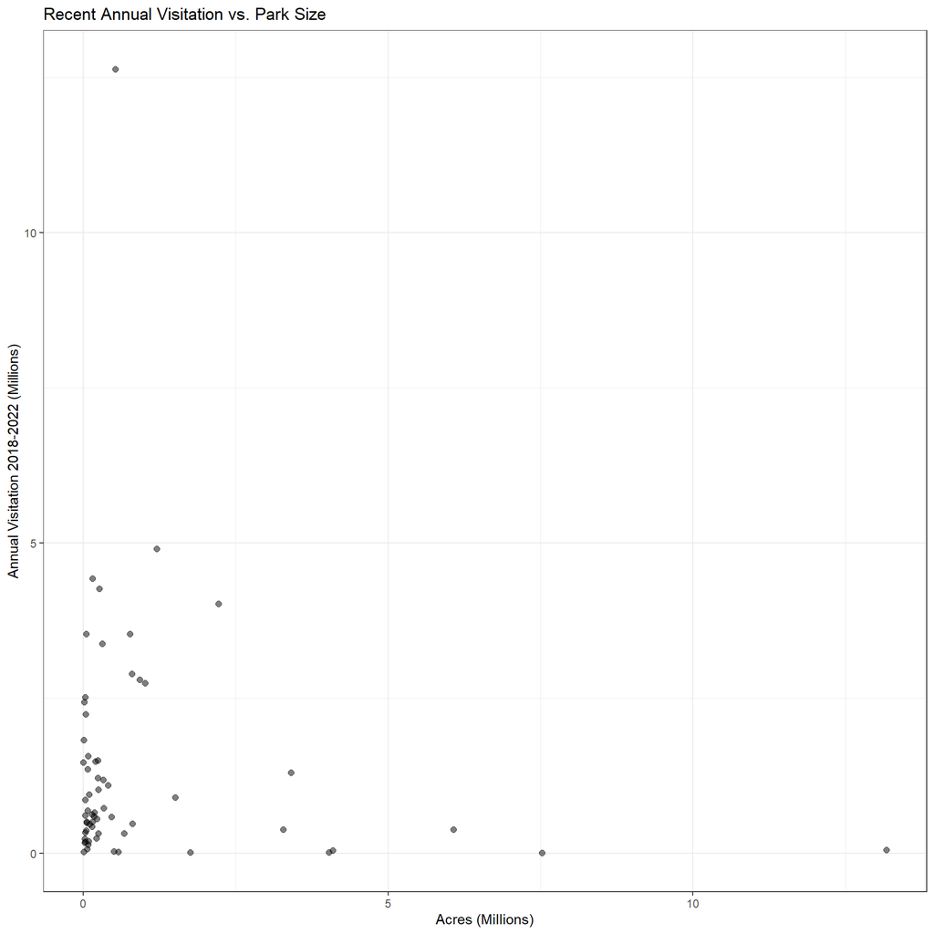

```r
park.data %>% ggplot(aes(x = `Acreage`/1000000, y = `5-year mean`/1000000)) +
  geom_point(size = 2, alpha = 0.5) +
  labs(x = "Acres (Millions)", y = "Annual Visitation 2018-2022 (Millions)", title = "Recent Annual Visitation vs. Park Size") +
  theme_bw()
```

This chart indicates that parks in close proximity to other parks might see more annual visitors, but I don’t think a strong conclusion can be drawn from this.

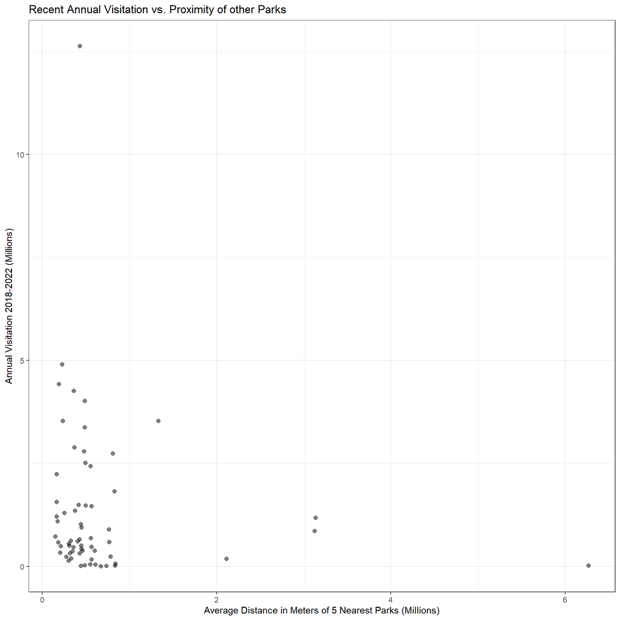

```r
park.data %>% ggplot(aes(x = `Average distance of 5 nearest parks (m)`/1000000, y = `5-year mean`/1000000)) +
  geom_point(size = 2, alpha = 0.5) +
  labs(x = "Average Distance in Meters of 5 Nearest Parks (Millions)", y = "Annual Visitation 2018-2022 (Millions)",
       title = "Recent Annual Visitation vs. Proximity of other Parks") +
  theme_bw()
```

The graph below shows how many parks each state/territory has.

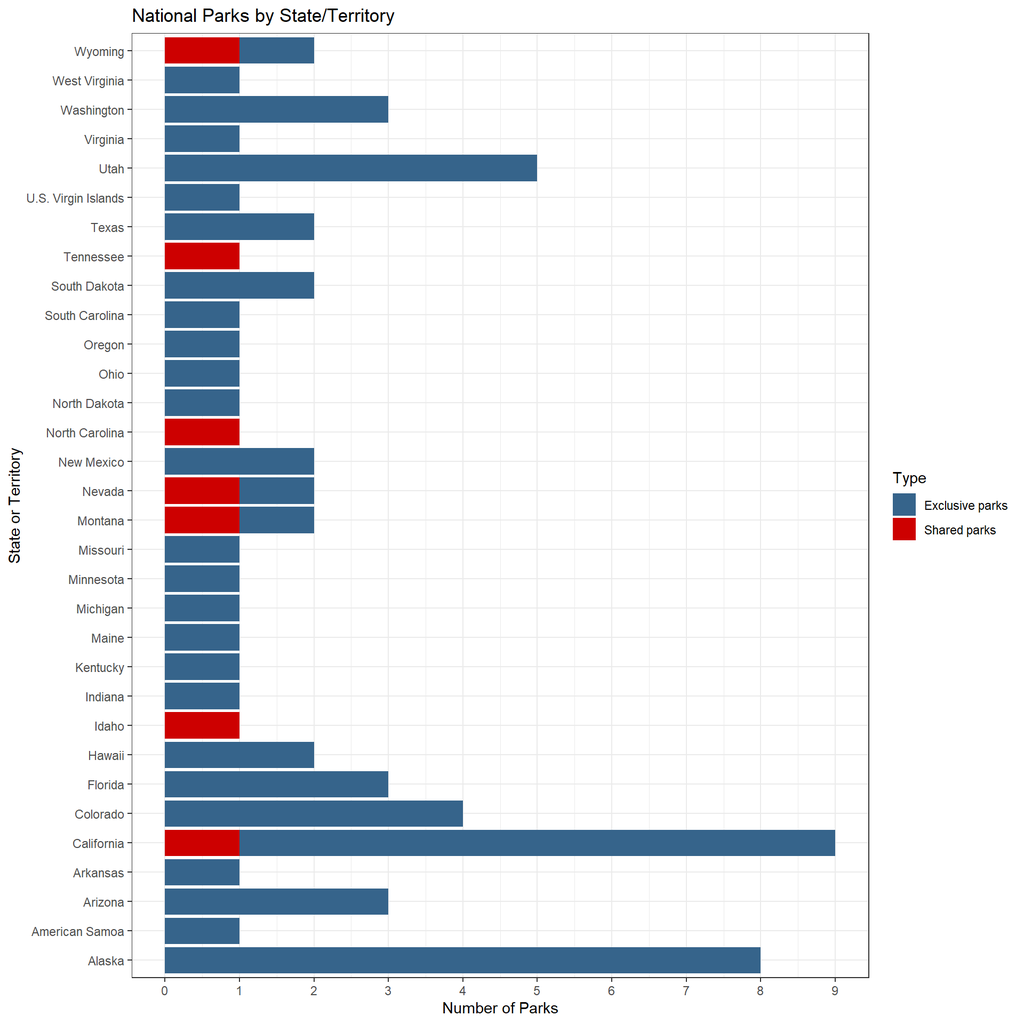

```r
pivot_longer(parkstates, c(`Exclusive parks`, `Shared parks`), names_to = "Type", values_to = "Amount") %>%
  ggplot(aes(fill = `Type`, x = `State`, y = `Amount`)) +
  geom_bar(position = "stack", stat = "identity") +
  scale_fill_manual(values = c("steelblue4", "red3")) +
  coord_flip() +
  scale_y_continuous(breaks = c(0:10)) +
  theme_bw() +
  labs(x = "State or Territory", y = "Number of Parks", title = "National Parks by State/Territory")
```

The next two charts show annual visitation over time for two very different parks: Crater Lake National Park and American Samoa National Park. An interesting thing to note is how the visitation took a dip in 2020 for American Samoa. Restrictions on international travel absolutely affected visitation.

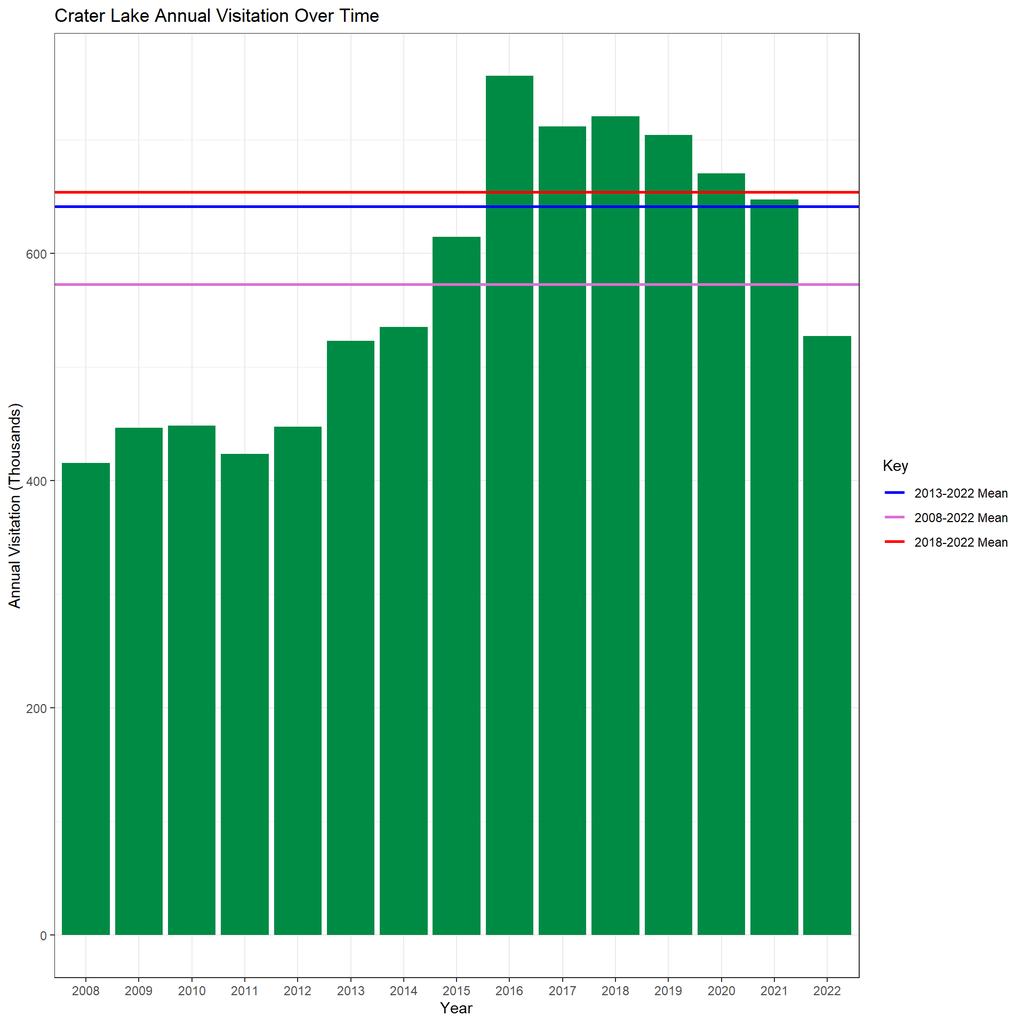

```r
park.data %>% filter(str_detect(park.data$`Park Name`, "Crater Lake")) %>%
pivot_longer(c(`2008`,`2009`,`2010`,`2011`,`2012`,`2013`,`2014`,`2015`,`2016`,`2017`,`2018`,
               `2019`,`2020`,`2021`,`2022`), names_to = "Year", values_to = "Number") %>%
  ggplot(aes(x = `Year`, y = `Number`/1000)) +
  geom_col(fill = "springgreen4") +
  theme_bw() +
  labs(y = "Annual Visitation (Thousands)", title = "Crater Lake Annual Visitation Over Time", color = "Key") +
  geom_hline(aes(yintercept = `5-year mean`/1000, color = "red"), size = 1) +
  geom_hline(aes(yintercept = `10-year mean`/1000, color = "blue"), size = 1) +
  geom_hline(aes(yintercept = `15-year mean`/1000, color = "orchid"), size = 1) +
  scale_color_identity(labels = c("2013-2022 Mean", "2008-2022 Mean", "2018-2022 Mean"), guide = "legend")
```

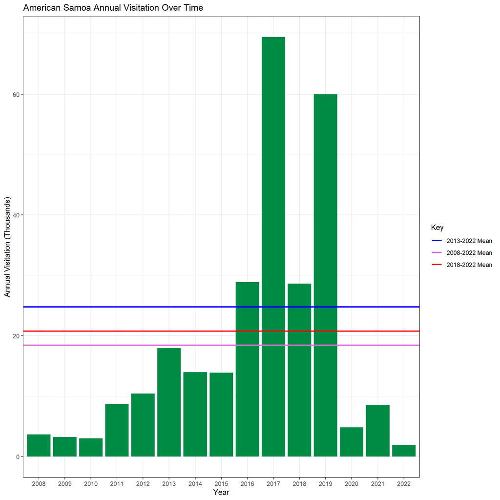

```r
park.data %>% filter(str_detect(park.data$`Park Name`, "Samoa")) %>%
pivot_longer(c(`2008`,`2009`,`2010`,`2011`,`2012`,`2013`,`2014`,`2015`,`2016`,`2017`,`2018`,
               `2019`,`2020`,`2021`,`2022`), names_to = "Year", values_to = "Number") %>%
  ggplot(aes(x = `Year`, y = `Number`/1000)) +
  geom_col(fill = "springgreen4") +
  theme_bw() +
  labs(y = "Annual Visitation (Thousands)", title = "American Samoa Annual Visitation Over Time", color = "Key") +
  geom_hline(aes(yintercept = `5-year mean`/1000, color = "red"), size = 1) +
  geom_hline(aes(yintercept = `10-year mean`/1000, color = "blue"), size = 1) +
  geom_hline(aes(yintercept = `15-year mean`/1000, color = "orchid"), size = 1) +
  scale_color_identity(labels = c("2013-2022 Mean", "2008-2022 Mean", "2018-2022 Mean"), guide = "legend")
```

[figure not shown]

```r
pivot_longer(park.data, c(`5-year % increase`, `10-year % increase`, `15-year % increase`),
             names_to = "Type", values_to = "Percent") %>%
  ggplot(aes(x = `Type`, y = `Percent`)) +
  geom_boxplot(fill = "#CEB1F8") +
  coord_flip() +
  theme_bw() +
  labs(y = "Percent Increase", x = "Years", title = "Percent Increases of Annual Park Visitation") +
  scale_x_discrete(labels=c("2018-2022", "2013-2022", "2008-2022")) +
  scale_y_continuous(breaks = c(-100,0,100,200,300,400,500,600,700,800,900,1000))
```

The boxplots below show annual visitation for each park grouped by year. The spread, as well as the average, steadily increases throughout the years until 2020 when visitation takes a dive.

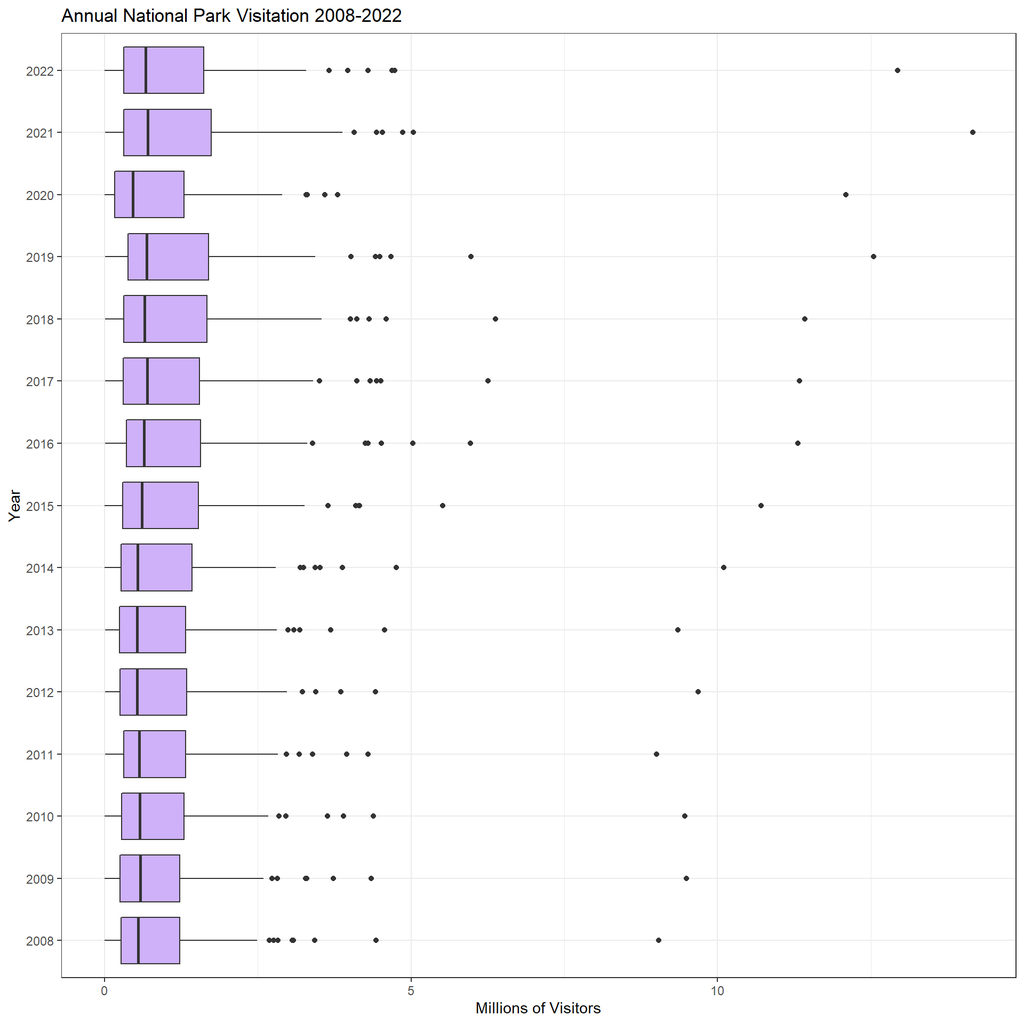

```r
pivot_longer(park.data, c(`2008`,`2009`,`2010`,`2011`,`2012`,`2013`,`2014`,`2015`,`2016`,`2017`,`2018`,
               `2019`,`2020`,`2021`,`2022`),
             names_to = "Year", values_to = "Number") %>%
  ggplot(aes(x = `Year`, y = `Number`/1000000)) +
  geom_boxplot(fill = "#CEB1F8") +
  coord_flip() +
  theme_bw() +
  labs(title = "Annual National Park Visitation 2008-2022", y = "Millions of Visitors")
```

This chart is similar to the boxplots above, but just shows total visitation for the National Parks by year. Again, we can see that there is an increase until 2020.

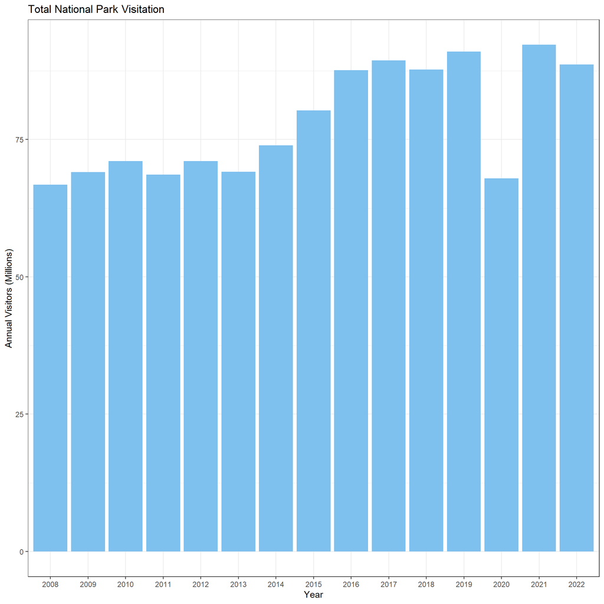

```r
sums <- colSums(park.data[ , 2:16]) %>%
  as.data.frame()
sums <- cbind(rownames(sums), sums)
colnames(sums) <- c("Year", "Num")
#wanted just the total visitation for each year over all the NPs

sums %>%
  ggplot(aes(x = `Year`, y = `Num`/1000000)) +
  geom_col(fill = "skyblue2") +
  theme_bw() +
  labs(y = "Annual Visitors (Millions)", title = "Total National Park Visitation")
```

The map below plots each park and shows the relative size and popularity of each park. The very dark park in the Eastern continental US is Great Smokey Mountains. We can also note that the Alaska parks all have significant acreage to them.

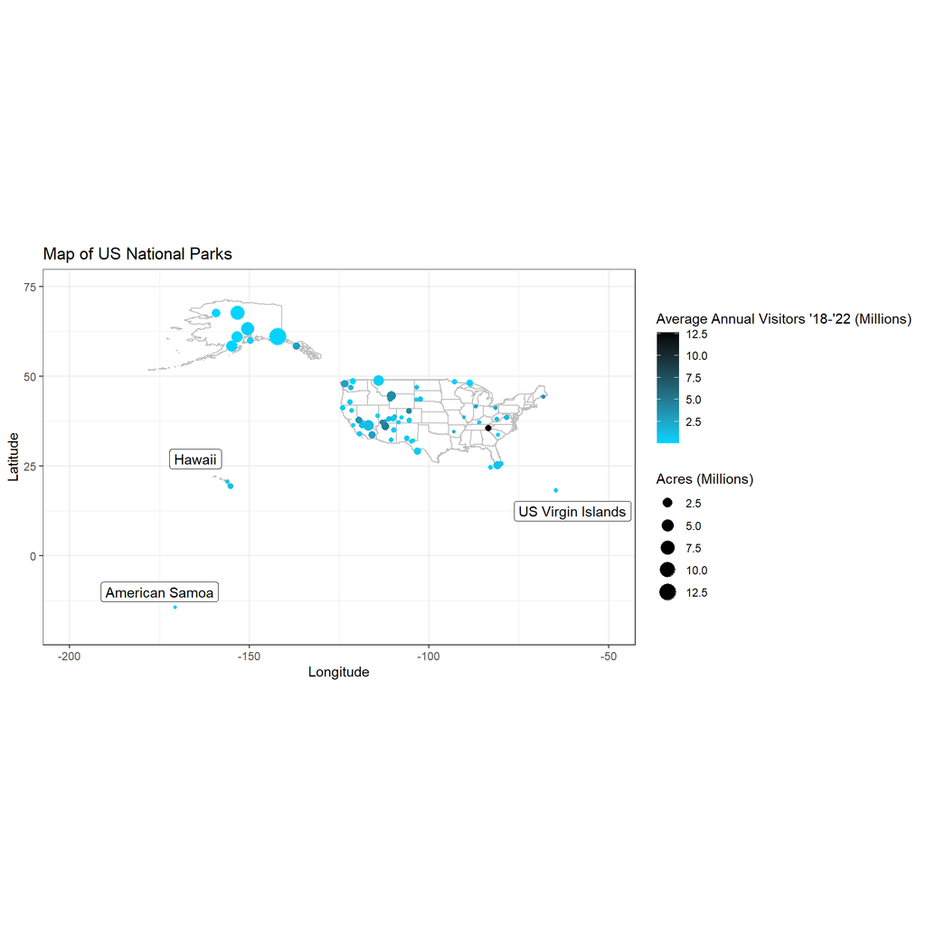

```r
us.map <- map_data("state") %>% select(long, lat, group, id = region)
#creates state map I used in combination with the world map
world.map <- map_data("world") %>% select(long, lat, group, id = region)
#this creates the world map
#(because the US state map does not include Alaska/Hawaii, let alone the US territories)

world.map %>% filter(str_detect(world.map$id, "American Samoa|Virgin Islands|USA")) %>%
  #I wanted to only map the US + American Samoa + US Virgin Islands
ggplot(aes(long, lat, group = group)) +
  geom_polygon(alpha = 0.5, fill = "white") +
  geom_path(color = "gray") +
  coord_equal() +
  scale_fill_identity() +
  theme(legend.position = "none") +
  #world map base
  geom_polygon(us.map, mapping = aes(long, lat, group = group), alpha = 0, fill = "white", color = "gray") +
  #overlayed the state outlines
  geom_point(park.data, mapping = aes(`Longitude`, `Latitude`, size = `Acreage`/1000000, color = `5-year mean`/1000000),
             alpha = 1, inherit.aes = FALSE) +
  #added the coordinates of the parks
  #made the color reflect average annual visitation over 2018-2022
  #made the size reflect acreage
  scale_color_gradient(low = "#00d4ff", high = "black") +
  xlim(-200,-50) +
  ylim(-20,75) +
  #cut down the map since I only needed a portion of it
  theme_bw() +
  labs(x = "Longitude", y = "Latitude", title = "Map of US National Parks",
       color = "Average Annual Visitors '18-'22 (Millions)", size = "Acres (Millions)") +
  geom_label(label="American Samoa", x = -175, y = -10) +
  geom_label(label="US Virgin Islands", x = -60, y = 12.5) +
  geom_label(label="Hawaii", x = -165, y = 27)
```

```r
#added labels for Hawaii, American Samoa, and US Virgin Islands
#because the dot pretty much covers the whole thing and they're all very small
```